# Lego Trends throughout the Years

Adrian Cariaga

January 11 2022

# Lego Trends throughout the Years

- We will take a look at various data about Lego sets. We will see trends in quantity of parts, themes and colors throughout the decades.

## Set up the environment

- We will install packages and libraries for data cleaning, transformation and visualization

```r
install.packages("ggplot2", repos = "http://cran.us.r-project.org")
install.packages("readr", repos = "http://cran.us.r-project.org")
install.packages("tidyverse", repos = "http://cran.us.r-project.org")
install.packages("RColorBrewer", repos = "http://cran.us.r-project.org")
install.packages("ggrepel", repos = "http://cran.us.r-project.org")
install.packages("treemap", repos = "http://cran.us.r-project.org")
install.packages("packcircles", repos = "http://cran.us.r-project.org")
```

## The following data will be used for cleaning, transformation and visualization

```
## [1] "D:/Files/Stuff/Important papers/Personal PC projects/Portfolio/R Markdown/Lego dataset"
```

```r
colors <- read.csv("colors.csv")
sets <- read.csv("sets.csv")
parts <- read.csv("parts.csv")
inventory_sets <- read.csv("inventory_sets.csv")
inventory <- read.csv("inventories.csv")
inventory_parts <- read.csv("inventory_parts.csv")
themes <- read.csv("themes.csv")
part_category <- read.csv("part_categories.csv")
```

## We will check number of unique colors

[output not shown]

## We will look at data from Sets

- Average Parts per Year from 1950 to 2020

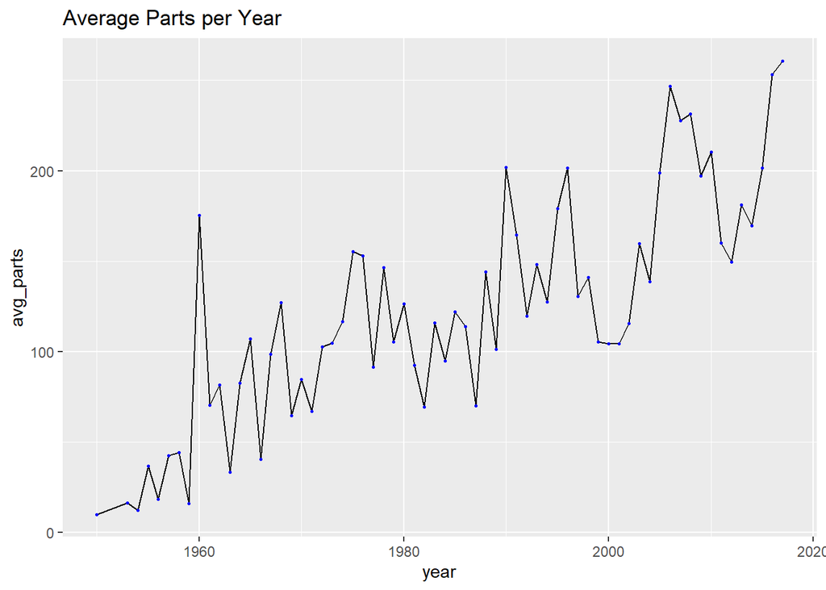

* The following shows Lego themes released per Year

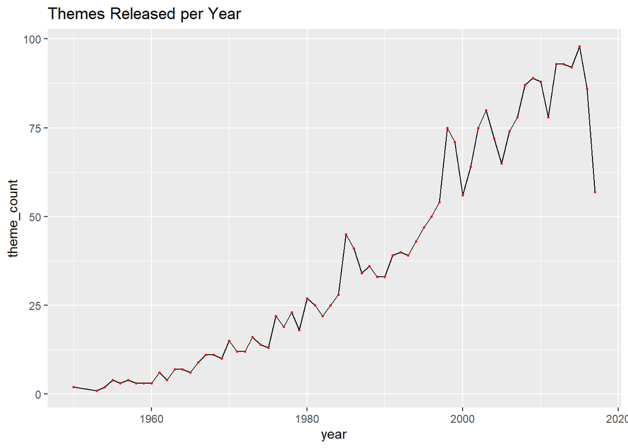

## The following data will highlight Lego parts

- We will look at the data structure of the “part_category” data

```
## 'data.frame':    57 obs. of  2 variables:
##  $ id  : int  1 2 3 4 5 6 7 8 9 10 ...
##  $ name: chr  "Baseplates" "Bricks Printed" "Bricks Sloped" "Duplo, Quatro and Primo" ...
```

```
##   id part_category_name part_num
## 1  1         Baseplates      901
## 2  1         Baseplates      902
## 3  1         Baseplates      903
## 4  1         Baseplates      904
## 5  1         Baseplates       10
## 6  1         Baseplates      10a
##                                                part_name
## 1      Baseplate 16 x 30 with Set 080 Yellow House Print
## 2 Baseplate 16 x 24 with Set 080 Small White House Print
## 3         Baseplate 16 x 24 with Set 080 Red House Print
## 4 Baseplate 16 x 24 with Set 080 Large White House Print
## 5                                      Baseplate 24 x 32
## 6                 Baseplate 24 x 32 with Squared Corners
```

- The following is a comparison of parts under a category within the Lego family

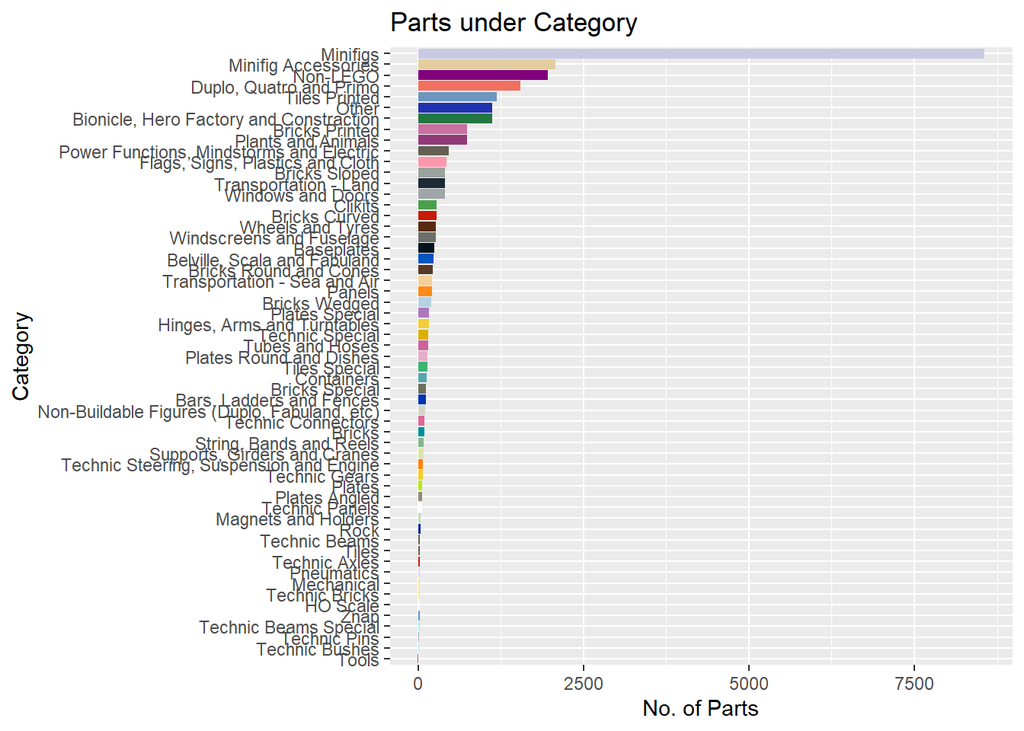

* The following data will take an in depth look at Lego parts

```
##   id part_category_name part_num
## 1  1         Baseplates      901
## 2  1         Baseplates      902
## 3  1         Baseplates      903
## 4  1         Baseplates      904
## 5  1         Baseplates       10
## 6  1         Baseplates      10a
##                                                part_name inventory_id color_id
## 1      Baseplate 16 x 30 with Set 080 Yellow House Print         1973        2
## 2 Baseplate 16 x 24 with Set 080 Small White House Print         1973        2
## 3         Baseplate 16 x 24 with Set 080 Red House Print         1973        2
## 4 Baseplate 16 x 24 with Set 080 Large White House Print         1973        2
## 5                                      Baseplate 24 x 32           NA       NA
## 6                 Baseplate 24 x 32 with Squared Corners         3591        2
##   quantity is_spare color_name     rgb is_trans
## 1        1        f      Green #237841        f
## 2        1        f      Green #237841        f
## 3        1        f      Green #237841        f
## 4        1        f      Green #237841        f
## 5       NA     <NA>       <NA>    <NA>     <NA>
## 6        1        f      Green #237841        f
```

- Now that we have set up a data frame for part colors, we will take a look at parts and colors used
- This chart will show number of unique parts per color

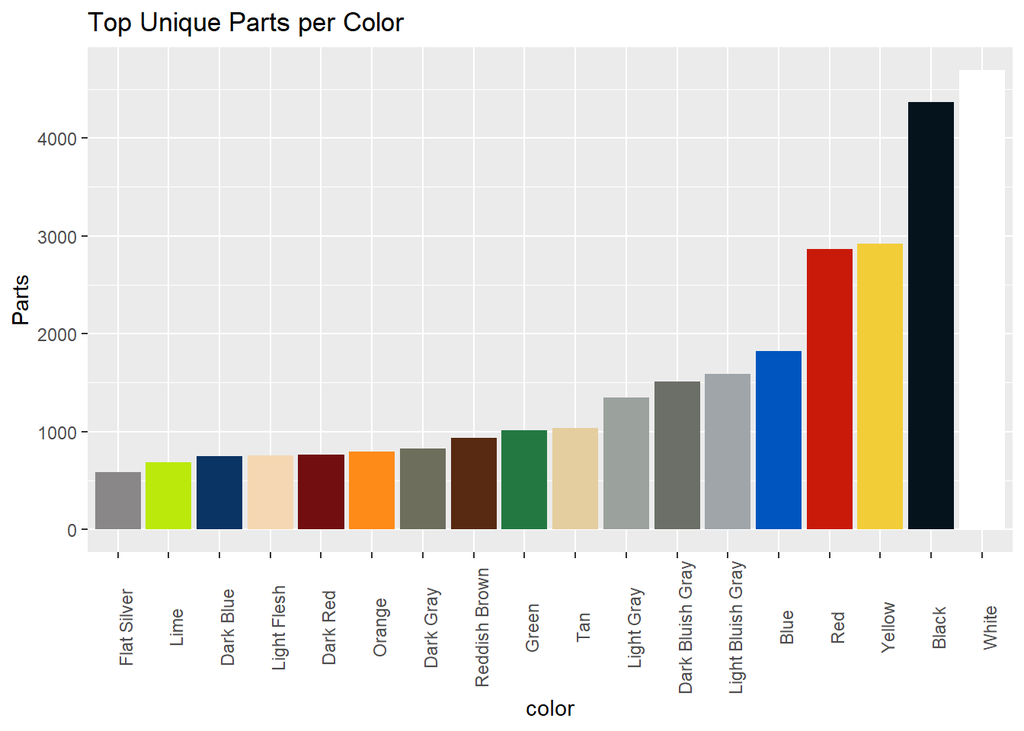

* This chart will show Lego sets with the maximum number of parts

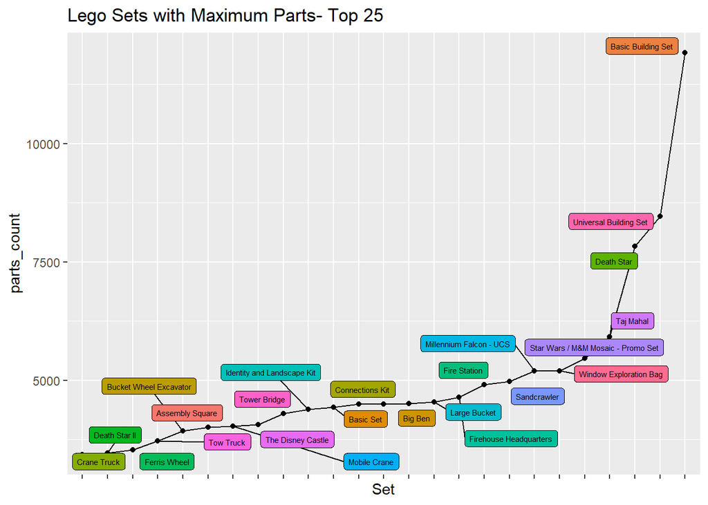

## We will now look at Lego themes and any data associated with it

- The following chart will show set counts in Lego themes

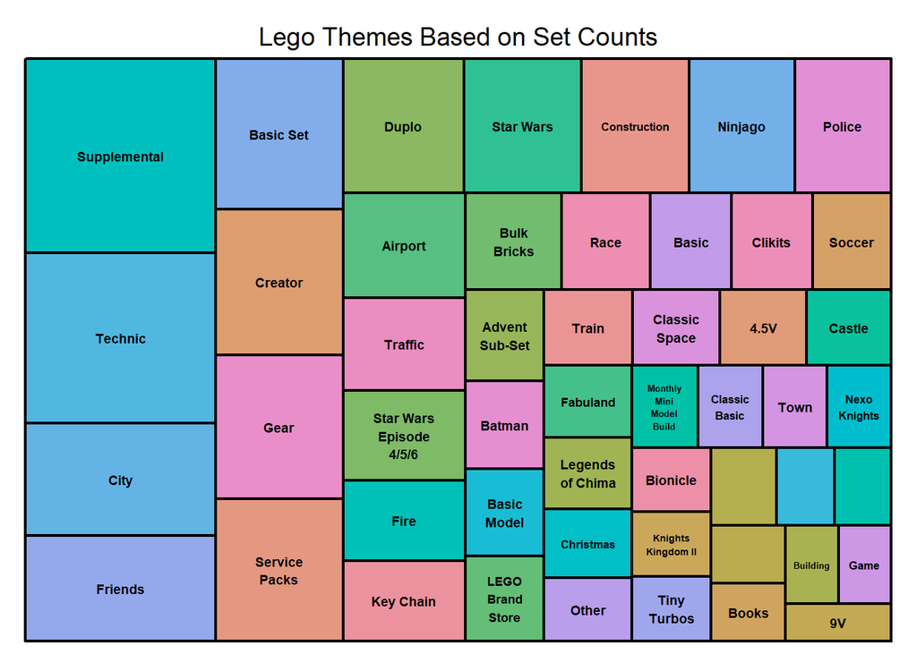

* The following is another way of looking at the top Lego themes

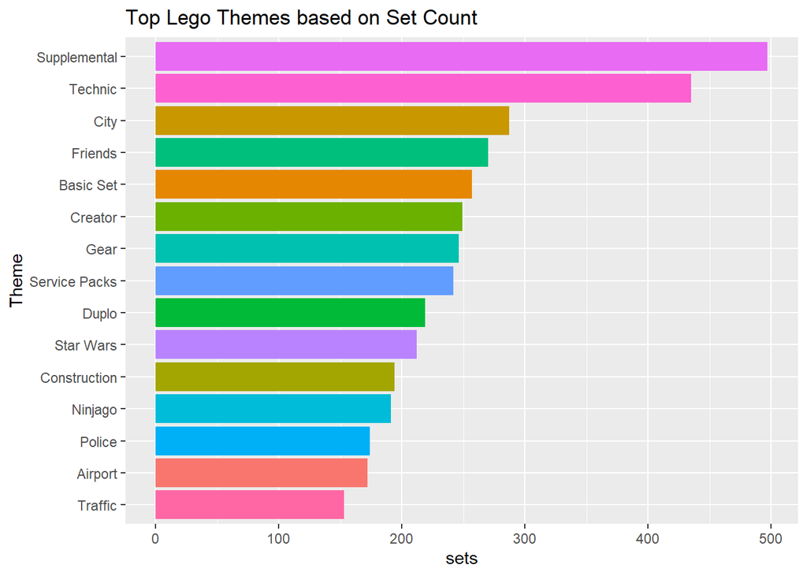

* We will look at two charts on popular lego themes throughout the years

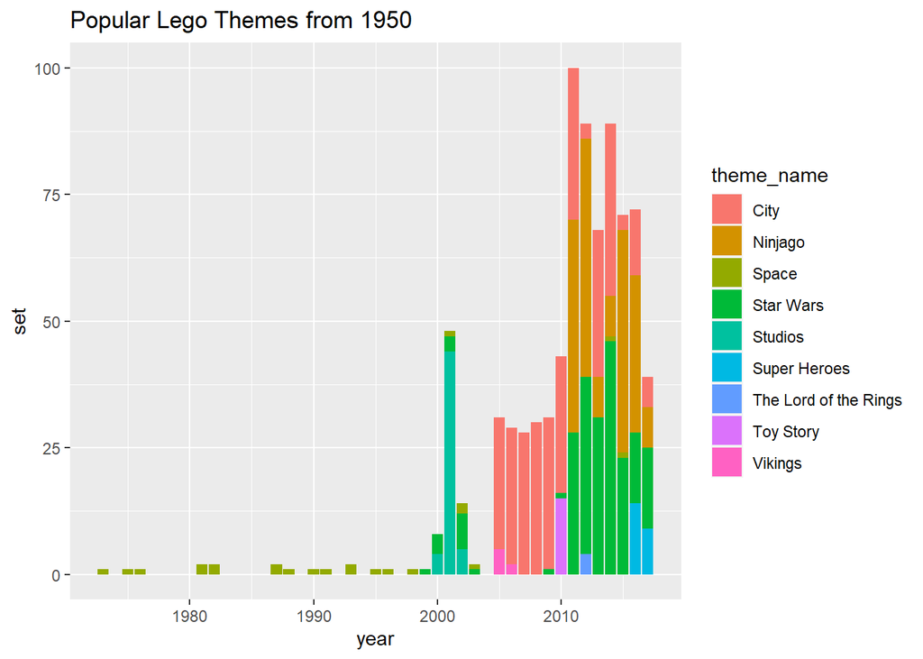

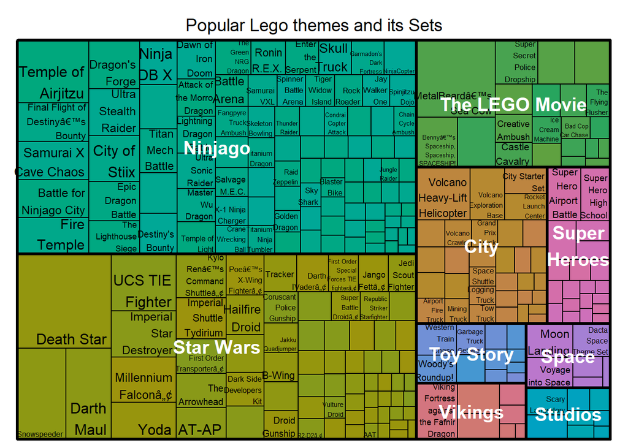

## We will now look at data on colors used for Lego parts

- First, we will organize and transform data on colors
- The following is a visualization of Lego colors used over 40 years

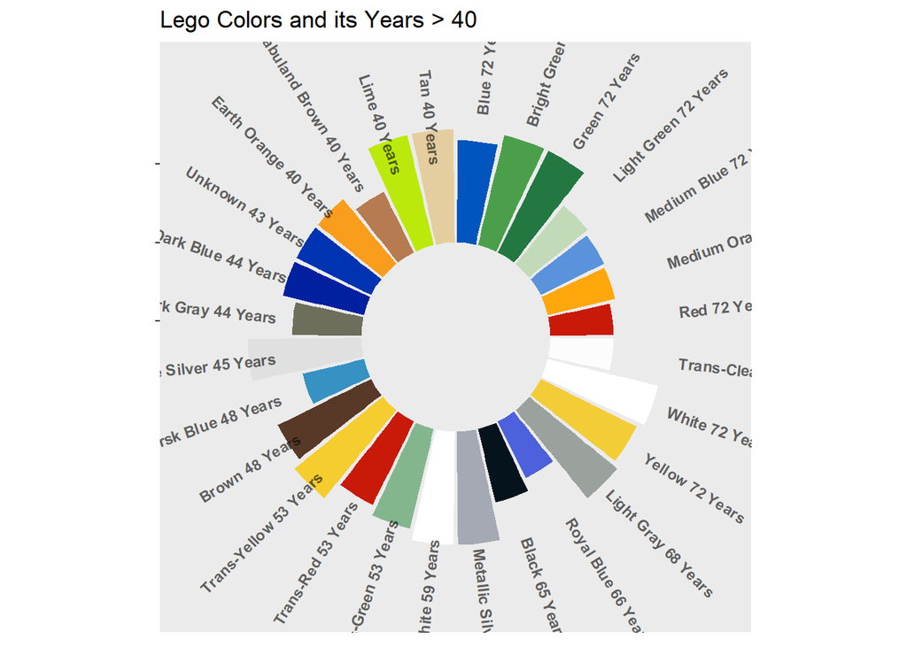

- Popular Lego colors in their sets

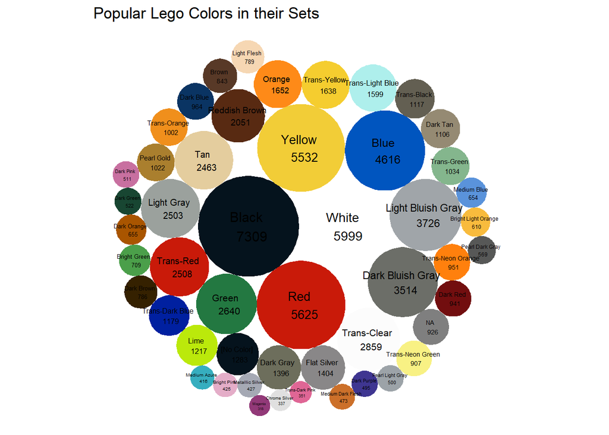

- This is a historical context of the count of Lego colors all the way from 1950

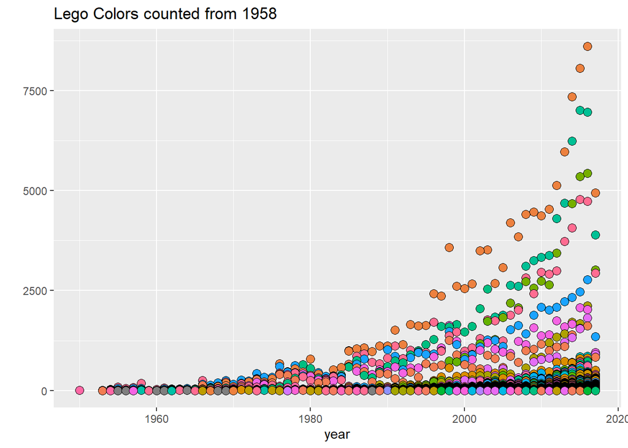

[output not shown]